# Homework 4

Supratik Pochampally

The purpose of this script is to run logistic regression and naive bayes over the Wisconisn Breast Cancer database, which has been clinically collected and reported in a paper by Wolberg and Mangasarian published in 1990. The objective of the database was to identify benign and malignant classes of tumors.

### Step 1

1. There are 699 instances in the BreastCancer dataframe.
2. The target column is Class.
3. There are 9 predictors, 5 of them being ordered factor integers and the other 4 being a factor integers.
4. 34.4778% of the observations are malignant.

```r
# Load the mlbench library and BreastCancer dataframe
library(mlbench)
data(BreastCancer)
# Run str(), head() on BreastCancer and summary() on just the Class column
str(BreastCancer)
```

```
## 'data.frame':    699 obs. of  11 variables:
##  $ Id             : chr  "1000025" "1002945" "1015425" "1016277" ...
##  $ Cl.thickness   : Ord.factor w/ 10 levels "1"<"2"<"3"<"4"<..: 5 5 3 6 4 8 1 2 2 4 ...
##  $ Cell.size      : Ord.factor w/ 10 levels "1"<"2"<"3"<"4"<..: 1 4 1 8 1 10 1 1 1 2 ...
##  $ Cell.shape     : Ord.factor w/ 10 levels "1"<"2"<"3"<"4"<..: 1 4 1 8 1 10 1 2 1 1 ...
##  $ Marg.adhesion  : Ord.factor w/ 10 levels "1"<"2"<"3"<"4"<..: 1 5 1 1 3 8 1 1 1 1 ...
##  $ Epith.c.size   : Ord.factor w/ 10 levels "1"<"2"<"3"<"4"<..: 2 7 2 3 2 7 2 2 2 2 ...
##  $ Bare.nuclei    : Factor w/ 10 levels "1","2","3","4",..: 1 10 2 4 1 10 10 1 1 1 ...
##  $ Bl.cromatin    : Factor w/ 10 levels "1","2","3","4",..: 3 3 3 3 3 9 3 3 1 2 ...
##  $ Normal.nucleoli: Factor w/ 10 levels "1","2","3","4",..: 1 2 1 7 1 7 1 1 1 1 ...
##  $ Mitoses        : Factor w/ 9 levels "1","2","3","4",..: 1 1 1 1 1 1 1 1 5 1 ...
##  $ Class          : Factor w/ 2 levels "benign","malignant": 1 1 1 1 1 2 1 1 1 1 ...
```

```r
head(BreastCancer)
```

|  | Id | Cl.thickness | Cell.size | Cell.shape | Marg.adhesion | Epith.c.size | Bare.nuclei | Bl.cromatin | Normal.nucleoli | Mitoses | Class |
| --- | --- | --- | --- | --- | --- | --- | --- | --- | --- | --- | --- |
| 1 | 1000025 | 5 | 1 | 1 | 1 | 2 | 1 | 3 | 1 | 1 | benign |
| 2 | 1002945 | 5 | 4 | 4 | 5 | 7 | 10 | 3 | 2 | 1 | benign |
| 3 | 1015425 | 3 | 1 | 1 | 1 | 2 | 2 | 3 | 1 | 1 | benign |
| 4 | 1016277 | 6 | 8 | 8 | 1 | 3 | 4 | 3 | 7 | 1 | benign |
| 5 | 1017023 | 4 | 1 | 1 | 3 | 2 | 1 | 3 | 1 | 1 | benign |
| 6 | 1017122 | 8 | 10 | 10 | 8 | 7 | 10 | 9 | 7 | 1 | malignant |

```r
summary(BreastCancer$Class)
```

```
##    benign malignant
##       458       241
```

```r
# Calculate the percentage of benign tumors and percentage of malignant tumors
benignPercentage <- length(which(BreastCancer$Class=="benign"))/nrow(BreastCancer)
malignantPercentage <- length(which(BreastCancer$Class=="malignant"))/nrow(BreastCancer)
# Print the percentages with proper labels
print(paste("Percentage of Benign tumors: ", benignPercentage))
```

```
## [1] "Percentage of Benign tumors:  0.655221745350501"
```

```r
print(paste("Percentage of Malignant tumors: ", malignantPercentage))
```

```
## [1] "Percentage of Malignant tumors:  0.344778254649499"
```

### Step 2

The following warning occurred:

Warning: glm.fit: fitted probabilities numerically 0 or 1 occurred

This warning is caused by the fact that our predictors may be completely or quasi-completely separated, meaning that the target variable completely separates the combinations of the two predictors Cell.size and Cell.shape. This is further supported by the unusually large standard error values for the predictors. One technique to solve separation or quasi-separation is to use naive bayes.

Source: From the [R documentation of the glm function](https://www.rdocumentation.org/packages/stats/versions/3.6.2/topics/glm) and the [UCLA Statistical Consulting page](https://stats.idre.ucla.edu/other/mult-pkg/faq/general/faqwhat-is-complete-or-quasi-complete-separation-in-logisticprobit-regression-and-how-do-we-deal-with-them/) on the topic.

```r
# Build a logistic regression model of the Class target variable using the Cell.size and Cell.shape predictor variables.
glm0 <- glm(Class~Cell.size+Cell.shape, data=BreastCancer, family=binomial)
```

```
## Warning: glm.fit: fitted probabilities numerically 0 or 1 occurred
```

```r
# Show the summary of the model to confirm that it built
summary(glm0)
```

```
##
## Call:
## glm(formula = Class ~ Cell.size + Cell.shape, family = binomial,
##     data = BreastCancer)
##
## Deviance Residuals:
##     Min       1Q   Median       3Q      Max
## -2.6380  -0.0844  -0.0844   0.0000   3.3583
##
## Coefficients:
##                Estimate Std. Error z value Pr(>|z|)
## (Intercept)     7.77977  757.06727   0.010    0.992
## Cell.size.L    10.45177  950.68968   0.011    0.991
## Cell.size.Q     0.04063 1479.65504   0.000    1.000
## Cell.size.C    10.70546  948.84001   0.011    0.991
## Cell.size^4    12.06582 1241.92612   0.010    0.992
## Cell.size^5     0.74199  792.70275   0.001    0.999
## Cell.size^6    -3.08210 1011.79270  -0.003    0.998
## Cell.size^7     7.47104 1044.50458   0.007    0.994
## Cell.size^8     5.60143  830.93455   0.007    0.995
## Cell.size^9   -10.22144 1812.16582  -0.006    0.995
## Cell.shape.L   18.15803 2619.03235   0.007    0.994
## Cell.shape.Q    9.14381 1500.17053   0.006    0.995
## Cell.shape.C    5.50082 1302.51283   0.004    0.997
## Cell.shape^4   -2.23752 2679.86462  -0.001    0.999
## Cell.shape^5   -5.76978 3193.32564  -0.002    0.999
## Cell.shape^6   -5.58415 2713.54558  -0.002    0.998
## Cell.shape^7   -3.94569 1740.80748  -0.002    0.998
## Cell.shape^8   -1.82009  827.39666  -0.002    0.998
## Cell.shape^9   -0.77209  257.90960  -0.003    0.998
##
## (Dispersion parameter for binomial family taken to be 1)
##
##     Null deviance: 900.53  on 698  degrees of freedom
## Residual deviance: 198.66  on 680  degrees of freedom
## AIC: 236.66
##
## Number of Fisher Scoring iterations: 19
```

### Step 3

I believe that making Cell.small and Cell.regular binary factors of Cell.size and Cell.shape was a good idea because it allows us to flatten the various values that the two predictors Cell.size and Cell.shape into binary factors.

```r
# Create two new columns of binary factors of Cell.size and Cell.shape.
BreastCancer$Cell.small <- factor(ifelse(BreastCancer$Cell.size == 1, 1, 0))
BreastCancer$Cell.regular <- factor(ifelse(BreastCancer$Cell.shape == 1, 1, 0))
# Print summary of Cell.size, Cell.regular, Cell.small, and Cell.regular
summary(BreastCancer[ ,c(3, 4, 12, 13)])
```

```
##    Cell.size     Cell.shape  Cell.small Cell.regular
##  1      :384   1      :353   0:315      0:346
##  10     : 67   2      : 59   1:384      1:353
##  3      : 52   10     : 58
##  2      : 45   3      : 56
##  4      : 40   4      : 44
##  5      : 30   5      : 34
##  (Other): 81   (Other): 95
```

### Step 4

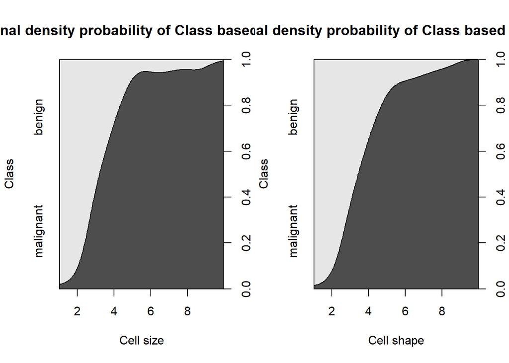

```r
# Attach the BreastCancer dataframe to reduce typing
attach(BreastCancer)
# Set up the 1x2 grid and plot the graphs using cdplot()
par(mfrow=c(1, 2))
cdplot(Class~Cell.size, main="Conditional density probability of Class based on Cell size", xlab="Cell size", ylab="Class")
cdplot(Class~Cell.shape, main="Conditional density probability of Class based on Cell shape", xlab="Cell shape", ylab="Class")
```

### Step 5

I believe the small and regular predictors will work well for this model, as we see a significant difference between the percentage of each that are malignant.

```r
# Calculate the percentages
sum(Cell.small==1 & Class=="malignant")/nrow(BreastCancer)
```

```
## [1] 0.005722461
```

```r
sum(Cell.small==0 & Class=="malignant")/nrow(BreastCancer)
```

```
## [1] 0.3390558
```

```r
sum(Cell.regular==1 & Class=="malignant")/nrow(BreastCancer)
```

```
## [1] 0.00286123
```

```r
sum(Cell.regular==0 & Class=="malignant")/nrow(BreastCancer)
```

```
## [1] 0.341917
```

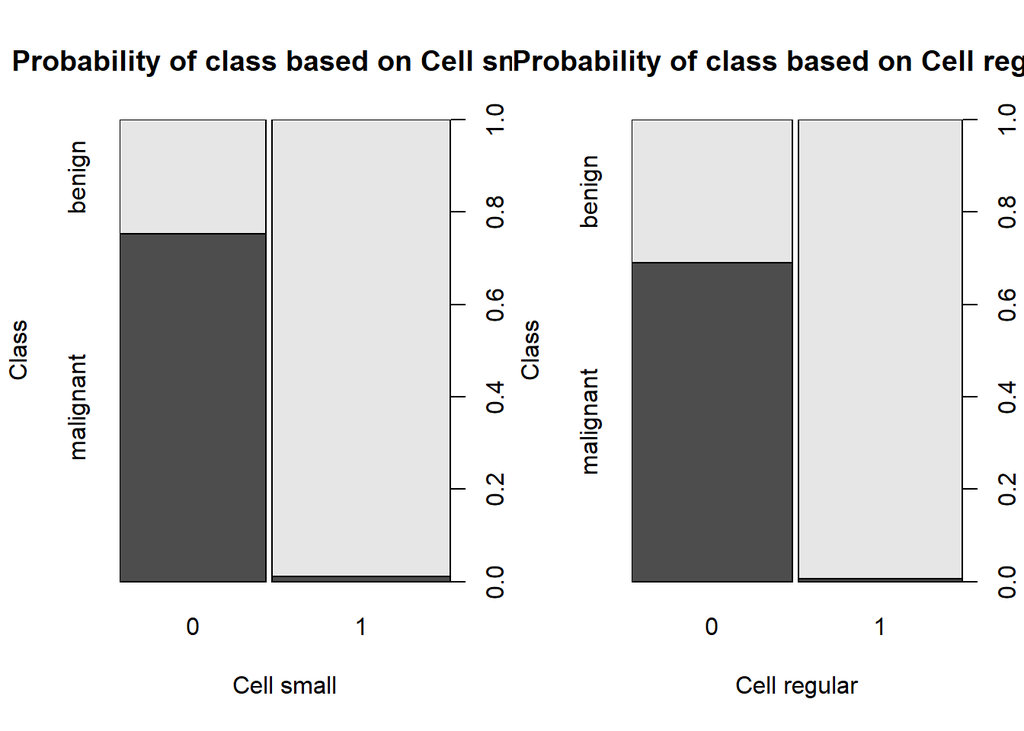

```r
# Create cdplot() graphs for the new columns
par(mfrow=c(1, 2))
plot(Class~Cell.small, main="Probability of class based on Cell small", xlab="Cell small", ylab="Class")
plot(Class~Cell.regular, main="Probability of class based on Cell regular", xlab="Cell regular", ylab="Class")
```

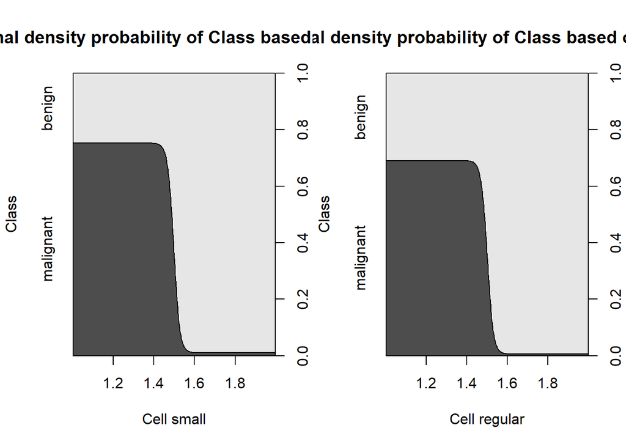

```r
cdplot(Class~Cell.small, main="Conditional density probability of Class based on Cell small", xlab="Cell small", ylab="Class")
cdplot(Class~Cell.regular, main="Conditional density probability of Class based on Cell regular", xlab="Cell regular", ylab="Class")
```

### Step 6

```r
# Set the seed so each run has the same train and test samples.
set.seed(1234)
# Split the data into train and test sets
i <- sample(1:nrow(BreastCancer), 0.8*nrow(BreastCancer), replace=FALSE)
train <- BreastCancer[i, ]
test <- BreastCancer[-i, ]
```

### Step 7

```r
# Build a logistic regression model for Class with the predictors Cell.small and Cell.regular
glm1 <- glm(Class~Cell.small+Cell.regular, data=train, family=binomial)
summary(glm1)
```

```
##
## Call:
## glm(formula = Class ~ Cell.small + Cell.regular, family = binomial,
##     data = train)
##
## Deviance Residuals:
##     Min       1Q   Median       3Q      Max
## -1.8314  -0.0445  -0.0445   0.6433   3.7198
##
## Coefficients:
##               Estimate Std. Error z value Pr(>|z|)
## (Intercept)     1.4701     0.1672   8.791  < 2e-16 ***
## Cell.small1    -4.6830     0.7411  -6.319 2.64e-10 ***
## Cell.regular1  -3.7044     0.7603  -4.873 1.10e-06 ***
## ---
## Signif. codes:  0 '***' 0.001 '**' 0.01 '*' 0.05 '.' 0.1 ' ' 1
##
## (Dispersion parameter for binomial family taken to be 1)
##
##     Null deviance: 721.78  on 558  degrees of freedom
## Residual deviance: 255.73  on 556  degrees of freedom
## AIC: 261.73
##
## Number of Fisher Scoring iterations: 8
```

### Step 8

The accuracy of the model is 0.8857.

There were more false positives than there were false negatives.

```r
# Import the caret package
library(caret)
# Test the model on the test data and calculate the probabilities and predictions
probs1 <- predict(glm1, newdata=test, type="response")
pred1 <- as.factor(ifelse(probs1>0.5, "malignant", "benign"))
# Output the confusion matrix
confusionMatrix(as.factor(pred1), reference=as.factor(test$Class))
```

```
## Confusion Matrix and Statistics
##
##            Reference
## Prediction  benign malignant
##   benign        79         2
##   malignant     14        45
##
##                Accuracy : 0.8857
##                  95% CI : (0.821, 0.9332)
##     No Information Rate : 0.6643
##     P-Value [Acc > NIR] : 1.386e-09
##
##                   Kappa : 0.759
##
##  Mcnemar's Test P-Value : 0.00596
##
##             Sensitivity : 0.8495
##             Specificity : 0.9574
##          Pos Pred Value : 0.9753
##          Neg Pred Value : 0.7627
##              Prevalence : 0.6643
##          Detection Rate : 0.5643
##    Detection Prevalence : 0.5786
##       Balanced Accuracy : 0.9035
##
##        'Positive' Class : benign
##
```

### Step 9

1. The coefficient of small is -4.682999
2. This coefficient quantifies a difference of -4.682999 in the log odds of the target variable.
3. The estimated probability of malignancy if Cell.small is true is 0.9166427%.
4. The probability of malignancy if Cell.small is true over the whole BreastCancer data set is 0.5722461. These values are only about 0.3443966% off, meaning that the coefficients of the logistic regression model are fairly accurate. However, this can be improved upon.

```r
# Show the coefficients of glm1
glm1$coefficients[]
```

```
##   (Intercept)   Cell.small1 Cell.regular1
##      1.470107     -4.682999     -3.704449
```

```r
# Calculate the estimated probability of a malignancy if Cell.small is true
exp(-4.682999)/(1 + exp(-4.682999))
```

```
## [1] 0.009166427
```

```r
# Calculate the probability of malignancy if Cell.small is true over the whole BreastCancer data set
sum(Class=="malignant" & Cell.small==1)/nrow(BreastCancer)
```

```
## [1] 0.005722461
```

### Step 10

Based on the anova() function, we can see that adding both Cell.small and Cell.regular (which are the predictors of the glm1 model) reduces the residual deviance the most to 255.7342. Furthermore, glm1 has the lowest AIC score of 261.7342 compared to glm_small’s score of 304.7544 and glm_regular’s score of 374.0222, showing that glm1 fits the data the best.

```r
# Build two more models each using Cell.small and Cell.regular
glm_small <- glm(Class~Cell.small, data=train, family=binomial)
glm_regular <- glm(Class~Cell.regular, data=train, family=binomial)
# Use anova() to compare the models and compare the AIC values
anova(glm_small, glm_regular, glm1)
```

|  | Resid. Df | Resid. Dev | Df | Deviance |
| --- | --- | --- | --- | --- |
| 1 | 557 | 300.7544 | NA | NA |
| 2 | 557 | 370.0222 | 0 | -69.26775 |
| 3 | 556 | 255.7342 | 1 | 114.28797 |

```r
AIC(glm_small)
```

```
## [1] 304.7544
```

```r
AIC(glm_regular)
```

```
## [1] 374.0222
```

```r
AIC(glm1)
```

```
## [1] 261.7342
```

### Step 11

1. 65.29517% of the training data is benign
2. Given that a sample is malignant, there is a 98.969072% likelihood that it is not small.
3. Given that a sample is malignant, there is a 98.969072% likelihood that it is not regular.

```r
# Load the e1071 library
library(e1071)
# Build a naive bayes model for Class using the Cell.small and Cell.regular predictors
nb1 <- naiveBayes(Class~Cell.small+Cell.regular, data=train)
nb1
```

```
##
## Naive Bayes Classifier for Discrete Predictors
##
## Call:
## naiveBayes.default(x = X, y = Y, laplace = laplace)
##
## A-priori probabilities:
## Y
##    benign malignant
## 0.6529517 0.3470483
##
## Conditional probabilities:
##            Cell.small
## Y                    0          1
##   benign    0.16438356 0.83561644
##   malignant 0.98969072 0.01030928
##
##            Cell.regular
## Y                    0          1
##   benign    0.23835616 0.76164384
##   malignant 0.98969072 0.01030928
```

### Step 12

The accuracy is 0.8857.

The results are the same, which is likely because there are a lot of observations, and as the number of training examples grows towards infinity, both naive bayes and logistic regression will converge to similar classifiers.

```r
# Predict the model on the test data
pred2 <- predict(nb1, newdata=test, type="class")
# Compute the accuracy and confusionMatrix
confusionMatrix(pred2, test$Class)
```

```
## Confusion Matrix and Statistics
##
##            Reference
## Prediction  benign malignant
##   benign        79         2
##   malignant     14        45
##
##                Accuracy : 0.8857
##                  95% CI : (0.821, 0.9332)
##     No Information Rate : 0.6643
##     P-Value [Acc > NIR] : 1.386e-09
##
##                   Kappa : 0.759
##
##  Mcnemar's Test P-Value : 0.00596
##
##             Sensitivity : 0.8495
##             Specificity : 0.9574
##          Pos Pred Value : 0.9753
##          Neg Pred Value : 0.7627
##              Prevalence : 0.6643
##          Detection Rate : 0.5643
##    Detection Prevalence : 0.5786
##       Balanced Accuracy : 0.9035
##
##        'Positive' Class : benign
##
```

```r
mean(pred2==test$Class)
```

```
## [1] 0.8857143
```